# EDA for Beginner

```python
%conda install numpy
```

[output not shown]

```python
pip install pillow
```

```python
pip install matplotlib
```

```python
pip install seaborn
```

```python
# Import Library:

from PIL import Image
import numpy as np
from matplotlib import pyplot as plt
import seaborn as sns
import pandas as pd
%matplotlib inline
```

# EXPLORATORY DATA ANALYSIS (EDA): A COMPREHENSIVE GUIDE FOR BEGINNER

## TABLE OF CONTENT:

1. INTRODUCTION

2. EDA PROCESS

3.1. Loading and Understanding dataset

3.2. Missing Data Treatment

3.3. Duplicated Treament

3.4. Data Type Identification

3.5. Tranformation of Variable

3.6. Univariate Analysis

3.7 Outlier Treament

3.8 Bivariate Analysis

4. INTRODUCE AUTO-EDA APPROACH: PROFILLING

EDA is the most important part of DS/DA Journey. Its usually takes aroung 70%-80% of time in any DS project cycle.

Exploratory data analysis(EDA) is used to explain how the data is, what is the relationship between the attributes, and furthermore.

EDA is not only about dealing with numbers but also understanding meaning relationships between attributes in the data.

An EDA helps us draw conclusions on how the data attributes are distributed.

Before going on to modeling an EDA should be done to understand the data and prepare for the modeling.

EDA is not just about numbers it is also a visual analysis of the data attributes using various graphs suited for each purpose.

A meaningful EDA must help in identifying patterns in the dataset.

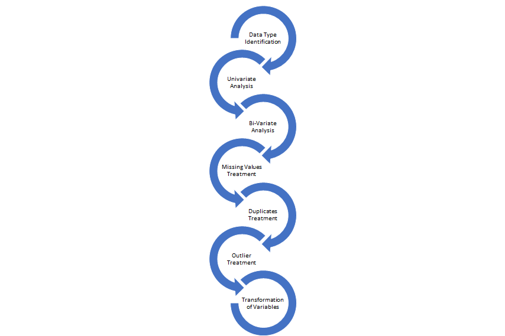

```python
img = Image.open('EDA.png')
img.show()
```

# 3.1 Loading and Understanding dataset

In this notebook, we will go through step by step of EDA progress. First, we will import the dataset and take a look of the data set to see what it offers

```python
# Import the dataset:
df= pd.read_csv('used_cars_2cities.csv')
pd.set_option('display.max_columns', None) # Display all the columns in the dataset
```

```python
df.head()
```

|  | v1 | price | area | subarea | name | condition | cylinders | drive | fuel | odometer | paintcolor | size | transmission | type | dealer |
| --- | --- | --- | --- | --- | --- | --- | --- | --- | --- | --- | --- | --- | --- | --- | --- |
| 0 | 1 | $4990 | chicago | chicago city | 2007 Toyota Camry Hybrid | good | 4 cylinders | fwd | gas | 116236.0 | grey | NaN | automatic | sedan | 1 |
| 1 | 2 | $10625 | chicago | chicago city | 2009 Toyota Camry Hybrid | NaN | 4 cylinders | fwd | hybrid | 43702.0 | grey | NaN | automatic | sedan | 1 |
| 2 | 3 | NaN | chicago | chicago city | 2010 Toyota Camry | excellent | NaN | fwd | gas | 140437.0 | white | mid-size | NaN | sedan | 1 |
| 3 | 4 | $14850 | chicago | chicago city | 2015 Toyota_ Camry_ | excellent | other | NaN | gas | 35721.0 | NaN | NaN | automatic | sedan | 1 |
| 4 | 5 | $15630 | chicago | chicago city | 2016 TOYOTA CAMRY | NaN | NaN | fwd | gas | 13152.0 | NaN | NaN | automatic | sedan | 1 |

```python
# Feature and Observation of the data:
print( 'Number of fearture is', len(df.columns))
print('Number of observation is', len(df.index))
```

```
Number of fearture is 15
Number of observation is 1095
```

# 3.2. Missing data Treatment:

```python
# check the number of missing data in each feature:
df.isnull().sum()
```

```
v1                0
price            84
area              0
subarea          34
name              0
condition       436
cylinders       374
drive           490
fuel              2
odometer        331
paintcolor      465
size            726
transmission      2
type            455
dealer            0
dtype: int64
```

So I will drop all the missing data.

```python
# Drop missing data
df= df.dropna(inplace= False)
# Now, check the missing data again
df.isnull().sum()
```

```
v1              0
price           0
area            0
subarea         0
name            0
condition       0
cylinders       0
drive           0
fuel            0
odometer        0
paintcolor      0
size            0
transmission    0
type            0
dealer          0
dtype: int64
```

# 3.3. Duplicated Treatment:

In this section, we will call out all the duplicates ( if any) and drop them

```python
# Check duplicates in the dataset
df.duplicated().sum()
```

```
0
```

There are no duplicates in the data set, we can move to the next step

# 3.4. Data Type Identification:

In this section we will check whether a feature is in this right type, and reform it if it is the wrong form.

```python
df.head()
```

|  | v1 | price | area | subarea | name | condition | cylinders | drive | fuel | odometer | paintcolor | size | transmission | type | dealer |
| --- | --- | --- | --- | --- | --- | --- | --- | --- | --- | --- | --- | --- | --- | --- | --- |
| 5 | 6 | $850 | chicago | chicago city | 1993 toyota camry | good | 6 cylinders | fwd | gas | 187000.0 | red | full-size | automatic | sedan | 0 |
| 10 | 11 | $2295 | chicago | chicago city | 2000 toyota camry le | excellent | 4 cylinders | fwd | gas | 107000.0 | white | mid-size | automatic | sedan | 0 |
| 16 | 17 | $4200 | chicago | chicago city | 2005 toyota camry LE | excellent | 6 cylinders | 4wd | gas | 120451.0 | grey | full-size | automatic | sedan | 0 |
| 23 | 24 | $7200 | chicago | chicago city | 2009 toyota camry se 4dr sedan | excellent | 4 cylinders | fwd | gas | 113300.0 | grey | mid-size | automatic | sedan | 0 |
| 28 | 29 | $14900 | chicago | chicago city | 2014 Toyota Camry XLE | like new | 4 cylinders | fwd | gas | 41539.0 | silver | mid-size | automatic | sedan | 0 |

# 3.5. Tranformation of Variable:

```python
# Data type identification:
df.info()
```

```
<class 'pandas.core.frame.DataFrame'>
Int64Index: 196 entries, 5 to 1087
Data columns (total 15 columns):
 #   Column        Non-Null Count  Dtype
---  ------        --------------  -----
 0   v1            196 non-null    int64
 1   price         196 non-null    object
 2   area          196 non-null    object
 3   subarea       196 non-null    object
 4   name          196 non-null    object
 5   condition     196 non-null    object
 6   cylinders     196 non-null    object
 7   drive         196 non-null    object
 8   fuel          196 non-null    object
 9   odometer      196 non-null    float64
 10  paintcolor    196 non-null    object
 11  size          196 non-null    object
 12  transmission  196 non-null    object
 13  type          196 non-null    object
 14  dealer        196 non-null    int64
dtypes: float64(1), int64(2), object(12)
memory usage: 24.5+ KB
```

- Variable V1 is such a mater of serial number, we can drop this columns.
- Variable odometer should be changed to int
- Variables Price and Cylinders suppose to be in int type.
- Variables Area, Subarea, name, condition, drive, fuel, paintcolor, size, transmission, type should be changed to categorical variables.

```python
# Drop v1:
df=df.drop(columns='v1',inplace= False)
```

```python
# Convert Odometer variable to int64 type:
df['odometer']= df['odometer'].astype('int')
```

```python
# Drop '$' from the price column:
df['price']= df['price'].str.strip('$')
# Tranform Price type to int:
df['price']=df['price'].astype('int')
```

```python
# Drop 'cylinders' from cylinders columns:
df['cylinders']=df['cylinders'].str.strip(' cylinders')
# Tranform Price type to int:
df['cylinders']=df['cylinders'].astype('category')
```

Before we tranform Area, Subarea, name, condition, drive, fuel, paintcolor, size, transmission, type variables we would know the unique value in each variable.

```python
# Call out the unique values in each column:
list=['area', 'subarea','condition',  'drive', 'fuel', 'paintcolor','size','transmission','type','name']

for i in list:
    print (i,df[i].unique())
```

```
area ['chicago' 'los angeles']
subarea ['chicago city' 'chicago N' 'chicago suburbs' 'indiana NW' 'chicago S'
 'chicago W' 'LA westside-southbay' 'San Fernando' 'LA long beach'
 'central LA' 'LA san gabriel']
condition ['good' 'excellent' 'like new' 'fair' 'new']
drive ['fwd' '4wd' 'rwd']
fuel ['gas' 'hybrid']
paintcolor ['red' 'white' 'grey' 'silver' 'blue' 'black' 'green' 'brown' 'yellow'
 'custom']
size ['full-size' 'mid-size' 'compact' 'sub-compact']
transmission ['automatic' 'manual']
type ['sedan' 'coupe' 'convertible']
name ['1993 toyota camry' '2000 toyota camry le' '2005 toyota camry LE'
 '2009 toyota camry se 4dr sedan' '2014 Toyota Camry XLE'
 '2012 toyota camry' '2012 TOYOTA CAMRY XLE' '2002 toyota camry le 4cyl'
 '2011 toyota camry se 4dr sedan' '2011 toyota camry hybrid'
 '2006 Toyota Camry Solara' '1998 Toyota Camry LX' '2008 toyota camry le'
 '2005 toyota camry le' '2000 toyota camry xle' '2000 Toyota_ Camry_'
 '2009 toyota camry le' '2011 toyota camry xle' '2013 Toyota_ Camry_'
 '2016 Toyota_ Camry_' '2004 toyota camry le 4dr sedan'
 '2004 toyota camry solara' '2012 toyota camry se 4dr sedan'
 '2001 toyota camry' '2002 toyota camry' '2005 toyota camry'
 '2006 toyota camry solara convertible' '2009 Toyota Camry SE'
 '2008 Toyota_ Camry_ Solara_' '2007 Toyota Camry'
 '2009 toyota camry hybrid' '2004 Toyota Camry le' '2001 Toyota Camry.'
 '2002 Toyota Camry LE Sedan' '2005 Toyota Camry' '2007 Toyota Camry se'
 '2014 toyota camry' '2007 toyota camry hybrid' '2006 Toyota_ Camry_'
 '2004 toyota camry' '2005 Toyota Camry V6' '2011 Toyota_ Camry_'
 '2006 TOYOTA CAMRY SE' '1999 toyota camry solara' '2002 toyota camry le'
 '2014 toyota camry xle' '1999 toyota camry le' '1997 toyota camry'
 '1994 toyota camry' '2011 toyota camry le' '2011 toyota camry'
 '2010 toyota camry' '2000 toyota camry' '2006 toyota camry solara'
 '2011 Toyota Camry' '2002 TOYOTA CAMRY LE' '1995 Toyota Camry LE'
 '2000 Toyota Camry' '2000 toyota camry le 4dr sedan' '2001 TOYOTA CAMRY'
 '1999 toyota camry' '1992 toyota camry' '1998 toyota camry le'
 '1999 Toyota Camry' '2000 toyota camry solara' '2014 toyota camry se'
 '2012 toyota Camry LE' '2005 Toyota Camry Le' '2007 TOYOTA CAMRY LE'
 '2007 Toyota Camry LE' '2007 toyota camry le 4dr sedan'
 '1995 toyota Camry Le' '2007 toyota camry le' '1998 toyota camry'
 '2015 Toyota Camry LE' '1997 Toyota camry' '2017 toyota camry se'
 '2010 toyota camry le 4dr sedan' '2006 Toyota  camry' '1999 Toyota camry'
 '2011 toyota camry le 4dr sedan' '2003 toyota camry le'
 '2013 TOYOTA CAMRY LE' '2012 Toyota Camry' '1998 Toyota Camry LE 4 DR'
 '1999 Toyota CAMRY' '2014 TOYOTA CAMRY SE SPORT' '2016 TOYOTA CAMRY SE'
 '2017 toyota camry' '1992 Toyota Camry' '1999 toyota camry xle'
 '2002 toyota camry xle' '2003 toyota camry' '2008 Toyota Camry Hybrid'
 '2017 toyota camry hybrid']
```

We could see the 'name' variables contain alot of dust, it needs to go through different process to be cleaned.

The wrangling process is beyond our scope of basic EDA for beginner, so I will skip this variable and continue working on with the rest in the list.

There are different approach to encoding categorical variable: Find and replace, label encoding, one-hot encoding, sklearn-pepline (for ML).

In this notebook I will implement the two basic approaches for beginner are Find and Place and Label encodeing:

```python
# Find and place appoach for the are and subarea variables:
cleanup_nums = {"area":     {"chicago": 0, "los angeles": 1},
                "subarea": {'chicago city':0, 'chicago N':1, 'chicago suburbs':2, 'indiana NW':3,  'chicago S':4,'chicago W':5, 'LA westside-southbay':6,'San Fernando':7,
                            'LA long beach':8, 'central LA':9, 'LA san gabriel':10 }
               }
```

```python
df = df.replace(cleanup_nums)
df.head(10)
```

|  | price | area | subarea | name | condition | cylinders | drive | fuel | odometer | paintcolor | size | transmission | type | dealer |
| --- | --- | --- | --- | --- | --- | --- | --- | --- | --- | --- | --- | --- | --- | --- |
| 5 | 850 | 0 | 0 | 1993 toyota camry | good | 6 | fwd | gas | 187000 | red | full-size | automatic | sedan | 0 |
| 10 | 2295 | 0 | 0 | 2000 toyota camry le | excellent | 4 | fwd | gas | 107000 | white | mid-size | automatic | sedan | 0 |
| 16 | 4200 | 0 | 0 | 2005 toyota camry LE | excellent | 6 | 4wd | gas | 120451 | grey | full-size | automatic | sedan | 0 |
| 23 | 7200 | 0 | 0 | 2009 toyota camry se 4dr sedan | excellent | 4 | fwd | gas | 113300 | grey | mid-size | automatic | sedan | 0 |
| 28 | 14900 | 0 | 0 | 2014 Toyota Camry XLE | like new | 4 | fwd | gas | 41539 | silver | mid-size | automatic | sedan | 0 |
| 37 | 8895 | 0 | 0 | 2012 toyota camry | like new | 4 | fwd | gas | 110 | blue | full-size | automatic | sedan | 0 |
| 38 | 8950 | 0 | 0 | 2012 TOYOTA CAMRY XLE | like new | 4 | fwd | gas | 110 | blue | full-size | automatic | sedan | 0 |
| 40 | 3750 | 0 | 1 | 2002 toyota camry le 4cyl | good | 4 | fwd | gas | 173906 | blue | mid-size | automatic | sedan | 0 |
| 42 | 6300 | 0 | 1 | 2011 toyota camry se 4dr sedan | excellent | 4 | fwd | gas | 156000 | black | full-size | automatic | sedan | 0 |
| 43 | 8499 | 0 | 1 | 2011 toyota camry hybrid | excellent | 4 | fwd | hybrid | 105 | green | full-size | automatic | sedan | 0 |

While this approach may only work in certain scenarios it is a very useful demonstration of how to convert text values to numeric when there is an “easy” human interpretation of the data. This concept is also useful for more general data cleanup.

```python
# Label Enconding for conditon, drive, fuel, paintcolor, size, tranmission, type variables:
# In this method, we will convert a column to a category, then use those category values for your label encoding:
```

```python
# Convert conditon, drive, fuel, paintcolor, size, type variables to categorical type:
list=['condition', 'drive', 'fuel', 'paintcolor', 'size', 'transmission', 'type']
for i in list:
    df[i]=df[i].astype('category')
print (df.dtypes)
```

```
price              int64
area               int64
subarea            int64
name              object
condition       category
cylinders       category
drive           category
fuel            category
odometer           int64
paintcolor      category
size            category
transmission    category
type            category
dealer             int64
dtype: object
```

```python
# Then we can assign the encoded variable to a new column using the cat.codes accessor:
for i in list:
    df[i]=df[i].cat.codes
df.head()
```

|  | price | area | subarea | name | condition | cylinders | drive | fuel | odometer | paintcolor | size | transmission | type | dealer |
| --- | --- | --- | --- | --- | --- | --- | --- | --- | --- | --- | --- | --- | --- | --- |
| 5 | 850 | 0 | 0 | 1993 toyota camry | 2 | 6 | 1 | 0 | 187000 | 6 | 1 | 0 | 2 | 0 |
| 10 | 2295 | 0 | 0 | 2000 toyota camry le | 0 | 4 | 1 | 0 | 107000 | 8 | 2 | 0 | 2 | 0 |
| 16 | 4200 | 0 | 0 | 2005 toyota camry LE | 0 | 6 | 0 | 0 | 120451 | 5 | 1 | 0 | 2 | 0 |
| 23 | 7200 | 0 | 0 | 2009 toyota camry se 4dr sedan | 0 | 4 | 1 | 0 | 113300 | 5 | 2 | 0 | 2 | 0 |
| 28 | 14900 | 0 | 0 | 2014 Toyota Camry XLE | 3 | 4 | 1 | 0 | 41539 | 7 | 2 | 0 | 2 | 0 |

The nice aspect of this approach is that you get the benefits of pandas categories (compact data size, ability to order, plotting support) but can easily be converted to numeric values for further analysis.

# 3.6. Univariate Analysis:

Some ways you can describe patterns found in univariate data include central tendency (mean, mode and median) and dispersion: range , variance, maximum, minimum, quartiles (including the interquartile range), and standard deviation.

## a) Descriptive Statistic:

Some ways you can describe patterns found in univariate data include central tendency (mean, mode and median) and dispersion: range , variance, maximum, minimum, quartiles (including the interquartile range), and standard deviation.

```python
df[['area', 'subarea','condition', 'drive', 'fuel', 'paintcolor', 'size', 'transmission', 'type','dealer']]=df[['area', 'subarea','condition', 'drive', 'fuel', 'paintcolor', 'size', 'transmission', 'type','dealer']].astype('category')


df.describe().T
```

|  | count | mean | std | min | 25% | 50% | 75% | max |
| --- | --- | --- | --- | --- | --- | --- | --- | --- |
| price | 196.0 | 6245.887755 | 4286.988756 | 361.0 | 2898.75 | 5222.5 | 8957.5 | 18500.0 |
| odometer | 196.0 | 109748.846939 | 62327.366793 | 80.0 | 60411.75 | 120225.5 | 157475.0 | 271000.0 |

## b) Univariate Data Visualizations:

### VISUALIZING UNIVARIATE CONTINUOUS DATA :

Univariate data visualization plots help us comprehend the enumerative properties as well as a descriptive summary of the particular data variable.

These plots help in understanding the location/position of observations in the data variable, its distribution, and dispersion

### Histogram:

A histogram displays the shape and spread of continuous sample data. It also helps us understand the skewness and kurtosis of the distribution of the data.

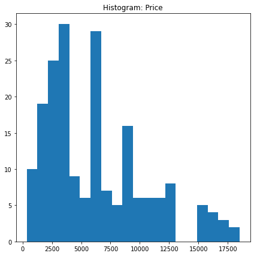

```python
#Plotting histogram using the matplotlib plt.hist() function :
plt.figure(figsize=(7,7))
plt.hist(df['price'],bins=20)
plt.title( 'Histogram: Price')
plt.show()
```

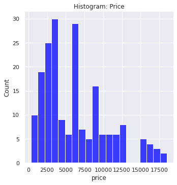

```python
# The seaborn function sns.distplot() can also be used to plot a histogram.
sns.set(rc={'figure.figsize': (7,7)})
sns.displot(df['price'],kde= False, color='blue', bins=20)
plt.title( 'Histogram: Price')
plt.show()
```

### Density Plot:

A density plot is like a smoother version of a histogram.

Generally, the kernel density estimate is used in density plots to show the probability density function of the variable.

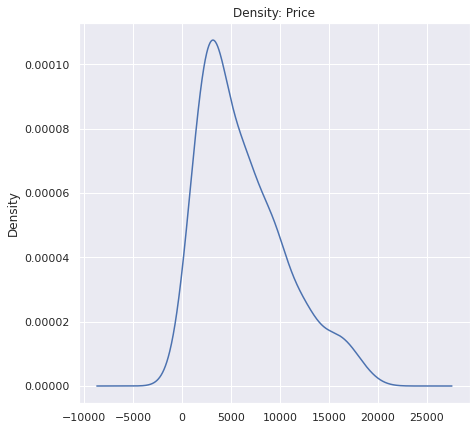

```python
plt.figure( figsize = (7,7))

df['price'].plot(kind= 'density')

plt.title('Density: Price')
plt.show()
```

### Univariate Scatter Plot:

Use the plt.scatter() function of matplotlib to plot a univariate scatter diagram. The scatter() function requires two parameters to plot.

We will plot the variable 'price' against 'odometer'

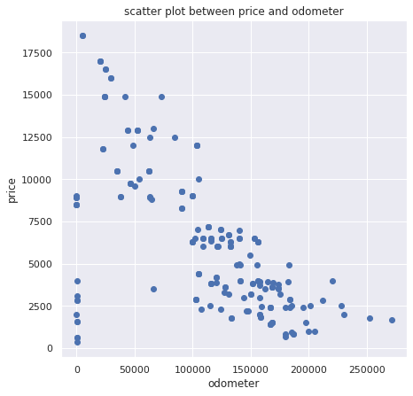

```python
plt.scatter(df['odometer'], df['price'])
plt.title ( 'scatter plot between price and odometer')
plt.xlabel('odometer')
plt.ylabel('price')
plt.show()
```

Then visualize the same plot by considering its variety using the sns.scatterplot() function of the seaborn library. This time we would like to see how price varies again odometer among different size ( 'full-size' 'mid-size' 'compact' 'sub-compact')

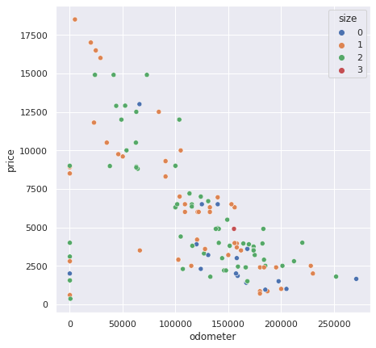

```python
sns.scatterplot(x=df['odometer'], y=df['price'], hue = df['size'])
```

One of the interesting features in seaborn is the ‘hue’ parameter.

In seaborn, the hue parameter determines which column in the data frame should be used for color encoding. This helps to differentiate between the data values according to the categories they belong to.

The hue parameter takes the grouping variable as it’s input using which it will produce points with different colors.

The variable passed onto ‘hue’ can be either categorical or numeric, although color mapping will behave differently in the latter case.

### Swam Plot:

The swam plot is similar to a scatter plot. It is often used along with other kinds of plots for better analysis. It is used to visualize the distribution of data points of the variable.

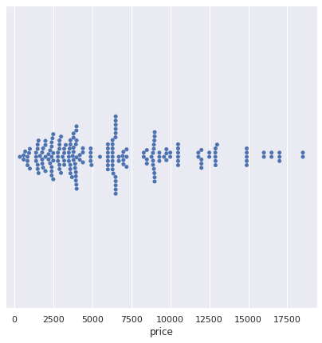

```python
sns.swarmplot(x=df['price'])
```

Distribution of the variable 'price' according to the 'size' categories:

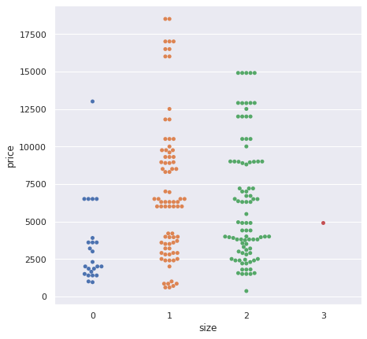

```python
sns.swarmplot(x=df['size'], y=df['price'])
```

### Box Plot:

A box-plot is a very useful and standardized way of displaying the distribution of data based on a five-number summary (minimum, first quartile, second quartile(median), third quartile, maximum). It helps in understanding these parameters of the distribution of data and is extremely helpful in detecting outliers.

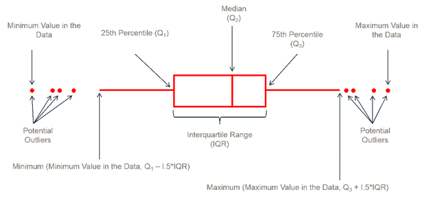

```python
img = Image.open('boxploy.png')
img.show()
```

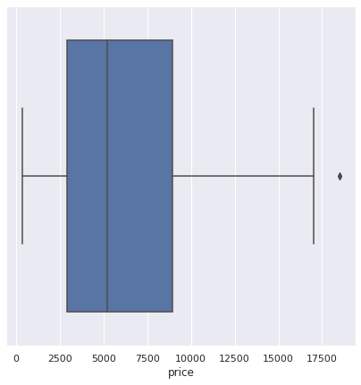

```python
sns.boxplot(df['price'])
```

We will plot the price in each condition for intensive analysis:

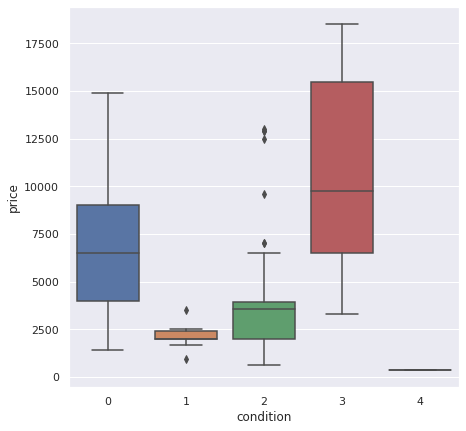

```python
sns.boxplot(x='condition', y='price', data =df)
```

## VISUALIZING CATEGORICAL VARIABLES:

### Bar Chart:

The bar plot is a univariate data visualization plot on a two-dimensional axis. One axis is the category axis indicating the category, while the second axis is the value axis that shows the numeric value of that category, indicated by the length of the bar. Let see, we would know number of each observation in each categorical variables:

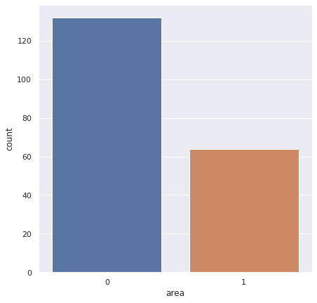

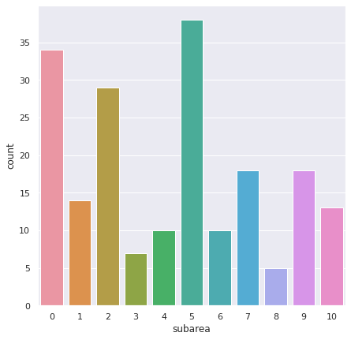

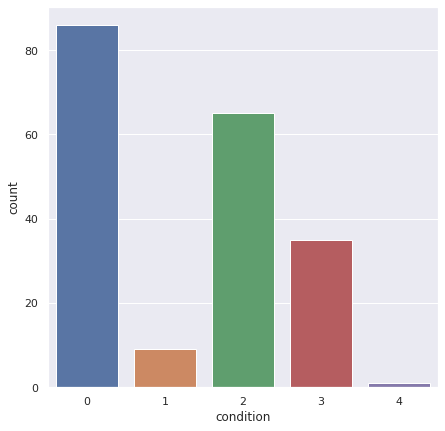

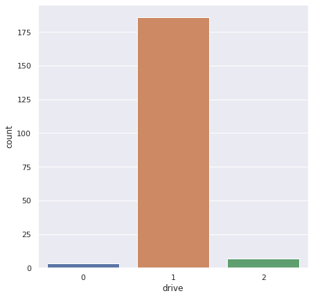

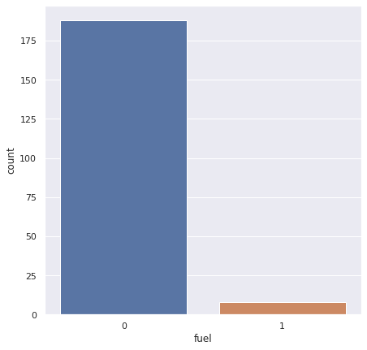

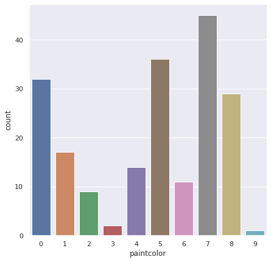

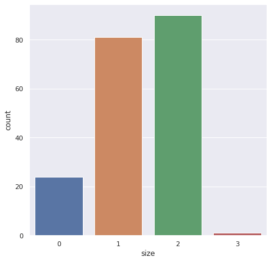

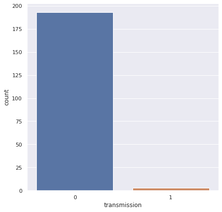

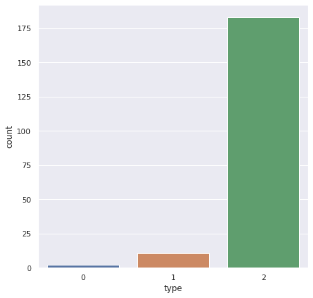

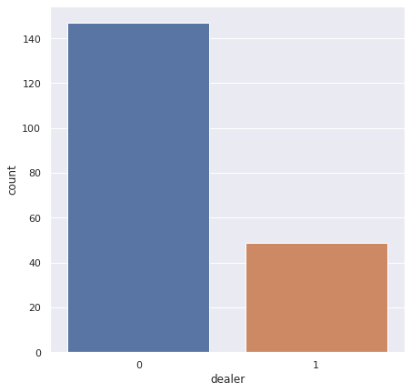

```python
list = ['area', 'subarea','condition', 'drive', 'fuel', 'paintcolor', 'size', 'transmission', 'type','dealer']
for i in list:
    sns.countplot(df[i])
    plt.show()
```

### Pie Chart:

A pie chart is the most common way used to visualize the numerical proportion occupied by each of the categories.

For example, I want to visualize the propotion of each categories for the 'type' variable

```
 [Text(-0.2275530841915859, -1.076206111242125, 'sedan'),
 [Text(-0.12411986410450139, -0.5870215152229772, '93.367'),
```

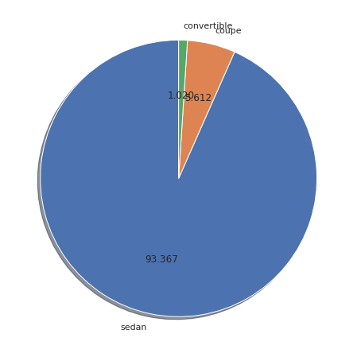

```python
plt.figure(figsize= (8,8))
plt.pie(df['type'].value_counts(), startangle=90, autopct= '%.3f',
        labels= ['sedan', 'coupe' ,'convertible'],
        shadow= True)
```

# 3.7. Outlier Treatment:

Before implementing any outlier trearment, we should plot boxplot for numerical variables:

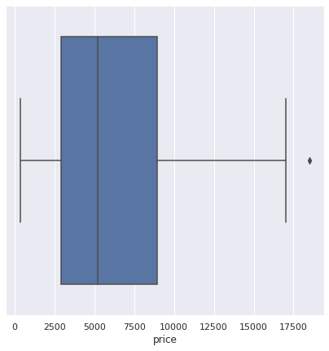

```python
sns.boxplot(df['price'])
```

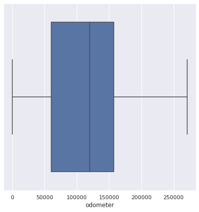

```python
sns.boxplot(df['odometer'])
```

The plots show no severe outlier. Together with the common senses, we can acept a used-car price runs from $361 to $18500 depend on different factors such as condition, type, size, color...

In general, there are 4 common methods to handling outlier:

- Pecentile Method
- Standard Deviation Method
- Z-Score Method
- IQR Method

Please refer to my notebook about detectinf and removing outier data for further understanding:

https://www.kaggle.com/code/ankumagawa/detect-and-remove-outlier

# 3.8. Bivariate Analysis:

The purpose of bivariate analysis is to understand the relationship between two variables

There are three common ways to perform bivariate analysis:

- Scatterplots
- Correlation Coefficients
- Simple Linear RegressionI

We did pratice the scatter plot between two variable in the Univariate Analysis section. Next part is how to analyze corellaction Coefficients between two varibles.

### Correlation Coefficient:

A Pearson Correlation Coefficient is a way to quantify the linear relationship between two variables.

We can use the corr() function in pandas to create a correlation matrix:

```python
corr = df.corr()
corr
```

|  | price | odometer |
| --- | --- | --- |
| price | 1.000000 | -0.634358 |
| odometer | -0.634358 | 1.000000 |

The below code shows how we can visualize the correlation between features in a matrix form:

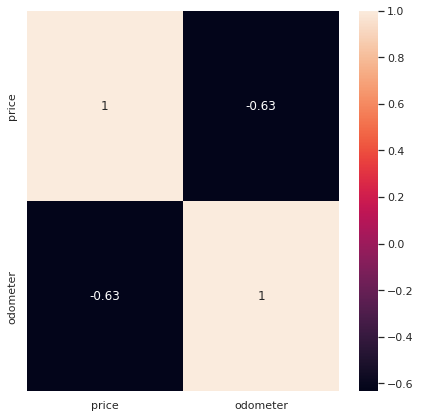

```python
sns.heatmap(corr,
            xticklabels= corr.columns.values,
            yticklabels= corr.columns.values,
            annot= True)
```

### Pair Plot:

Instead of plotting to scatter plots individually, we can also plot a pair plot.

It’ll plot a scatter plot for every feature with every other feature.

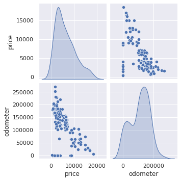

```python
sns.pairplot(df, diag_kind = 'kde')
plt.show()
```

### Simple Linear Regression:

Simple linear regression is a statistical method we can use to quantify the relationship between two variables.

We can use the OLS() function from the statsmodels package to quickly fit a simple linear regression model for price and odometer:

```python
import statsmodels.api as sm

#define dependent variable:
y=df['price']

#define independent variable:
x= df['odometer']

# add constant to predictor variables:
x= sm.add_constant(x)

#fit linear regression model:
model= sm.OLS(y,x).fit()

#view model summary:
print(model.summary())
```

```
                            OLS Regression Results
==============================================================================
Dep. Variable:                  price   R-squared:                       0.402
Model:                            OLS   Adj. R-squared:                  0.399
Method:                 Least Squares   F-statistic:                     130.6
Date:                Mon, 04 Apr 2022   Prob (F-statistic):           1.83e-23
Time:                        09:24:45   Log-Likelihood:                -1866.4
No. Observations:                 196   AIC:                             3737.
Df Residuals:                     194   BIC:                             3743.
Df Model:                           1
Covariance Type:            nonrobust
==============================================================================
                 coef    std err          t      P>|t|      [0.025      0.975]
------------------------------------------------------------------------------
const       1.103e+04    481.510     22.916      0.000    1.01e+04     1.2e+04
odometer      -0.0436      0.004    -11.430      0.000      -0.051      -0.036
==============================================================================
Omnibus:                       18.003   Durbin-Watson:                   1.784
Prob(Omnibus):                  0.000   Jarque-Bera (JB):               30.762
Skew:                          -0.494   Prob(JB):                     2.09e-07
Kurtosis:                       4.671   Cond. No.                     2.56e+05
==============================================================================

Notes:
[1] Standard Errors assume that the covariance matrix of the errors is correctly specified.
[2] The condition number is large, 2.56e+05. This might indicate that there are
strong multicollinearity or other numerical problems.
```

The fitted regression equation turns out to be:

Price = 11030 - 0.0436*(odometer)

This tells us that each additional odometer is associated with an average decrease of $0.0436 in used_car's price.

EDA can be automated using a Python library called Pandas Profiling. It is a great tool to create reports in the interactive HTML format which is quite easy to understand and analyze data.

Let’s explore Pandas Profiling to do EDA in a very short time and with just a single line code.

Python provides certain open-source modules that can automate the whole process of EDA and save a lot of time. Some of which I have used and are very resourceful are listed below:

- Pandas Profiling
- Sweetviz
- Autoviz

In the context of this notebook, I only introduce the first method: pandas profiling. I wrote another notebook to introduce ohter auto-EDA method here: https://www.kaggle.com/code/ankumagawa/automatic-eda-with-dataprep-autoviz-profiling

For further research, please take a look to my notebook.

```python
# Installing the pandas profiling:
```

```python
pip install pandas-profiling
```

```python
from pandas_profiling import ProfileReport
profiling= pd.read_csv('used_cars_2cities.csv')
profiling
```

|  | v1 | price | area | subarea | name | condition | cylinders | drive | fuel | odometer | paintcolor | size | transmission | type | dealer |
| --- | --- | --- | --- | --- | --- | --- | --- | --- | --- | --- | --- | --- | --- | --- | --- |
| 0 | 1 | $4990 | chicago | chicago city | 2007 Toyota Camry Hybrid | good | 4 cylinders | fwd | gas | 116236.0 | grey | NaN | automatic | sedan | 1 |
| 1 | 2 | $10625 | chicago | chicago city | 2009 Toyota Camry Hybrid | NaN | 4 cylinders | fwd | hybrid | 43702.0 | grey | NaN | automatic | sedan | 1 |
| 2 | 3 | NaN | chicago | chicago city | 2010 Toyota Camry | excellent | NaN | fwd | gas | 140437.0 | white | mid-size | NaN | sedan | 1 |
| 3 | 4 | $14850 | chicago | chicago city | 2015 Toyota_ Camry_ | excellent | other | NaN | gas | 35721.0 | NaN | NaN | automatic | sedan | 1 |
| 4 | 5 | $15630 | chicago | chicago city | 2016 TOYOTA CAMRY | NaN | NaN | fwd | gas | 13152.0 | NaN | NaN | automatic | sedan | 1 |
| ... | ... | ... | ... | ... | ... | ... | ... | ... | ... | ... | ... | ... | ... | ... | ... |
| 1090 | 1195 | $3300 | los angeles | central LA | 2012 Toyota Camry | like new | 4 cylinders | fwd | gas | NaN | NaN | NaN | automatic | NaN | 0 |
| 1091 | 1196 | $1100 | los angeles | LA westside-southbay | 2003 Toyota Camry Xle | NaN | NaN | NaN | gas | NaN | NaN | NaN | automatic | NaN | 0 |
| 1092 | 1197 | $3700 | los angeles | San Fernando | 2003 toyota camry | NaN | NaN | NaN | gas | 132000.0 | NaN | NaN | automatic | NaN | 0 |
| 1093 | 1198 | $1502 | los angeles | LA san gabriel | 2009 toyota camry se | excellent | 4 cylinders | fwd | gas | NaN | black | NaN | automatic | NaN | 0 |
| 1094 | 1199 | $3700 | los angeles | San Fernando | 2003 toyota camry | excellent | 4 cylinders | NaN | gas | 132000.0 | NaN | NaN | automatic | NaN | 0 |

1095 rows × 15 columns

```python
# Drop '$' from the price column:
profiling['price']= profiling['price'].str.strip('$')
profiling[['area','subarea', 'name', 'condition', 'cylinders', 'drive','paintcolor', 'size','transmission', 'type','dealer']]= profiling[['area','subarea', 'name', 'condition', 'cylinders', 'drive','paintcolor', 'size','transmission', 'type','dealer']].astype('category')
```

```python
design_report = ProfileReport(profiling)
design_report
```

[interactive chart not shown]

## Reference:

https://www.analyticsvidhya.com/blog/2020/07/univariate-analysis-visualization-with-illustrations-in-python/

https://towardsdatascience.com/exploring-univariate-data-e7e2dc8fde80

https://pbpython.com/categorical-encoding.html

https://www.kaggle.com/code/ankumagawa/automatic-eda-with-dataprep-autoviz-profiling

https://www.kaggle.com/code/ankumagawa/detect-and-remove-outlier

https://www.statology.org/bivariate-analysis-in-python/

https://www.analyticsvidhya.com/blog/2020/07/univariate-analysis-visualization-with-illustrations-in-python/

https://towardsdatascience.com/exploratory-data-analysis-dcb5e7189c4e